# RR_report_Kondratovych_Slabon

Claudia Słaboń, Kateryna Kondratovych

09 June, 2021

## COVID-19 and it’s impact on unemployment rate

The first cases of COVID-19 comes from China (Wuhan) and were discovered in November 2019. From the beginning of the 2020 new outbreaks of the coronavirus have started to appear in other countries. The pandemic spread around the world rapidly. The discovery of the easily contagious virus forced on the world’s government to take an fast and unconventional actions. Many countries have closed their borders and introduced lockdown. Due to such actions many economies suffer from a pandemic.  
The aim of this report is to discover whether the COVID-19 had an impact on unemployment. Firsly, it will be examined from the point of view of OECD countries, G7 countries, the USA. After that, the situation in Poland will be presented.

Dataset sources:  
- Wikipedia information regarding coronavirus cases.  
- Monthly unemployment rate in OECD countries comes from the OECD website.  
- Poland unemployment rate in voivodships comes from Poland’s Central Statistical Office.  
- Poland map was built from dataset introduced during the classes.

# COVID-19 spread

Although, the first cases of coronavirus were discover in China in the late of 2019, the pandemic rapidly spread around the whole world. Currently, there is **174,125,069** coronavirus cases, **3,750,197** people died (09 June, 2021 update).  
Official top 3 countries with **highest** COVID-19 cases number:  
- United States (33,547,199 cases),  
- India (29,089,069 cases),  
- Brazil (17,038,260 cases).

# Unemployment rate in OECD countries

Below graphs present the situation of unemployment rate in OECD countries. It means that the unemployment rate is captured in 37 countries.

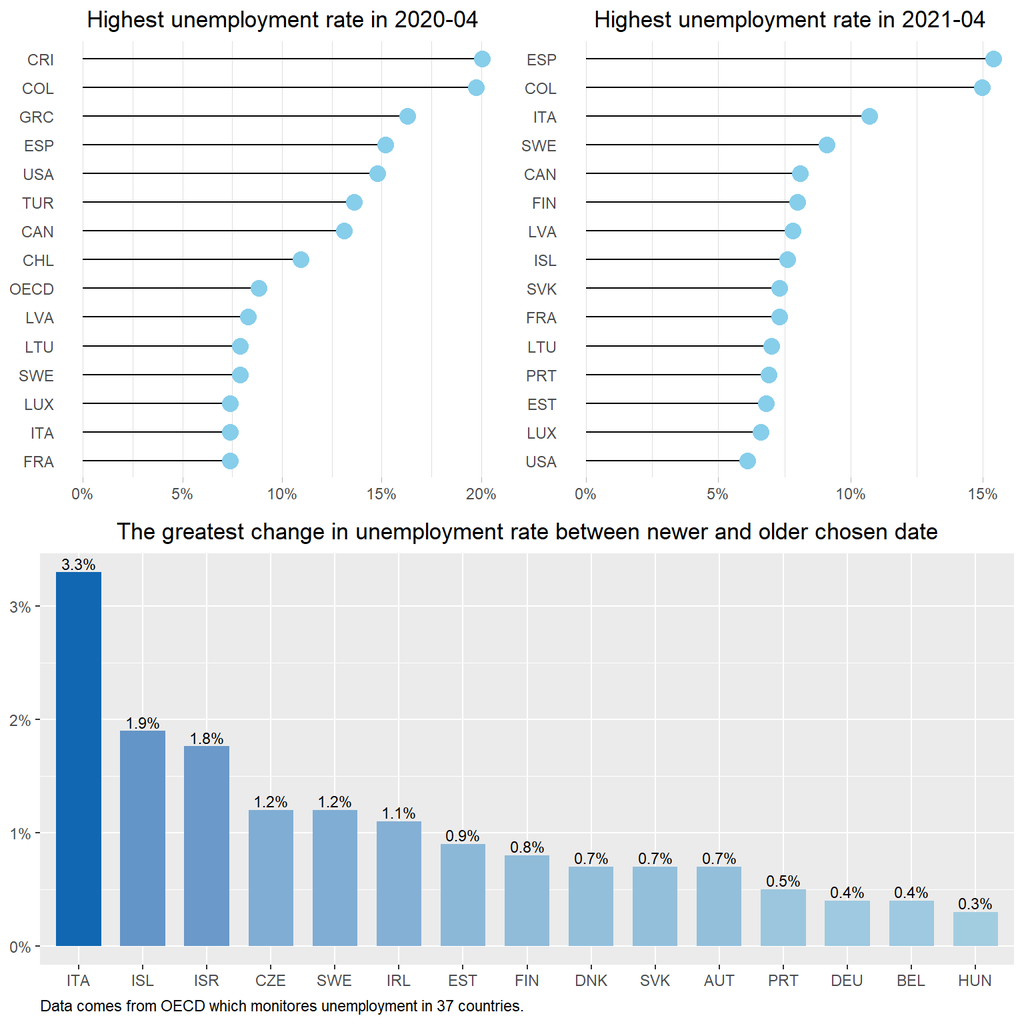

# Country-specific unemployment rate

One can chose any country and get country-specific report

[interactive chart not shown]

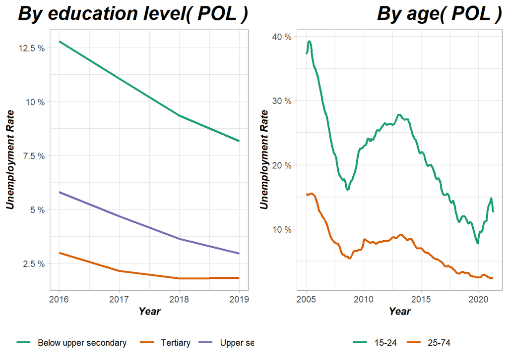

## Forecast

We also did some forecasting using ARIMA. We used function auto-arima to find the best parameters.

```
##            [,1]
## 2000-12-01 16.8
## 2001-01-01 17.1
## 2001-02-01 17.4
## 2001-03-01 17.7
## 2001-04-01 18.1
## 2001-05-01 18.4
```

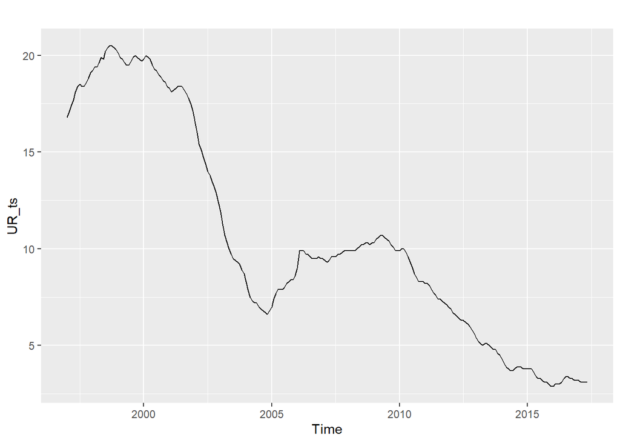

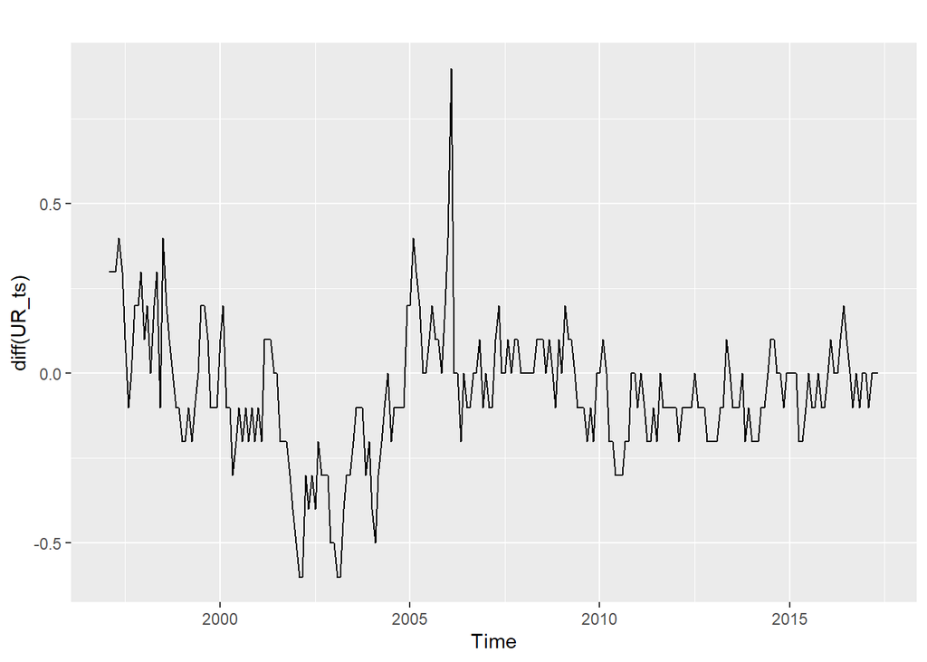

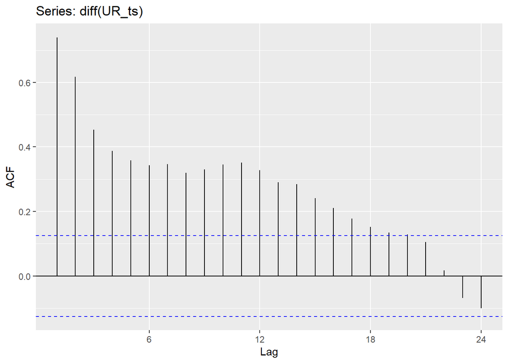

```
## [1] 0.01192257
```

```
## [1] "ok"
```

```
##
##  Fitting models using approximations to speed things up...
##
##  ARIMA(2,1,2)(1,0,1)[12] with drift         : -312.6321
##  ARIMA(0,1,0)            with drift         : -108.7181
##  ARIMA(1,1,0)(1,0,0)[12] with drift         : -307.8759
##  ARIMA(0,1,1)(0,0,1)[12] with drift         : -226.1317
##  ARIMA(0,1,0)                               : -90.48257
##  ARIMA(2,1,2)(0,0,1)[12] with drift         : -309.2965
##  ARIMA(2,1,2)(1,0,0)[12] with drift         : -312.3843
##  ARIMA(2,1,2)(2,0,1)[12] with drift         : -333.4897
##  ARIMA(2,1,2)(2,0,0)[12] with drift         : -335.5864
##  ARIMA(1,1,2)(2,0,0)[12] with drift         : -333.1777
##  ARIMA(2,1,1)(2,0,0)[12] with drift         : -337.1392
##  ARIMA(2,1,1)(1,0,0)[12] with drift         : -313.1164
##  ARIMA(2,1,1)(2,0,1)[12] with drift         : -335.108
##  ARIMA(2,1,1)(1,0,1)[12] with drift         : -314.1705
##  ARIMA(1,1,1)(2,0,0)[12] with drift         : -332.2236
##  ARIMA(2,1,0)(2,0,0)[12] with drift         : -333.7869
##  ARIMA(3,1,1)(2,0,0)[12] with drift         : -334.3744
##  ARIMA(1,1,0)(2,0,0)[12] with drift         : -328.5463
##  ARIMA(3,1,0)(2,0,0)[12] with drift         : -334.4836
##  ARIMA(3,1,2)(2,0,0)[12] with drift         : -332.688
##  ARIMA(2,1,1)(2,0,0)[12]                    : -334.2453
##
##  Now re-fitting the best model(s) without approximations...
##
##  ARIMA(2,1,1)(2,0,0)[12] with drift         : -315.7639
##
##  Best model: ARIMA(2,1,1)(2,0,0)[12] with drift
```

```
## Series: UR_ts
## ARIMA(2,1,1)(2,0,0)[12] with drift
##
## Coefficients:
##          ar1     ar2     ma1    sar1     sar2    drift
##       0.2212  0.4760  0.3741  0.0758  -0.1832  -0.0538
## s.e.  0.1853  0.1336  0.2015  0.0670   0.0692   0.0321
##
## sigma^2 estimated as 0.0154:  log likelihood=165.12
## AIC=-316.24   AICc=-315.76   BIC=-291.76
##
## Training set error measures:
##                        ME      RMSE        MAE        MPE     MAPE       MASE
## Training set -0.001081206 0.1222982 0.09234395 0.01085794 1.094762 0.06791711
##                      ACF1
## Training set -0.002100423
```

[output not shown]

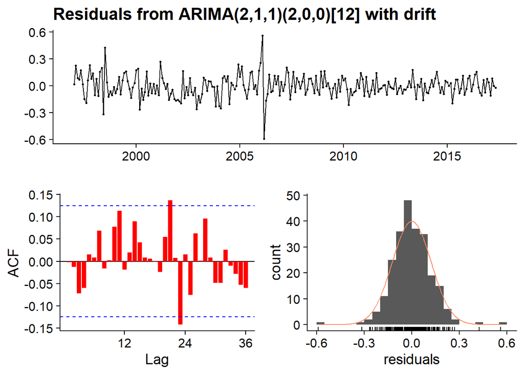

```
##
##  Ljung-Box test
##
## data:  Residuals from ARIMA(2,1,1)(2,0,0)[12] with drift
## Q* = 22.909, df = 18, p-value = 0.1941
##
## Model df: 6.   Total lags used: 24
```

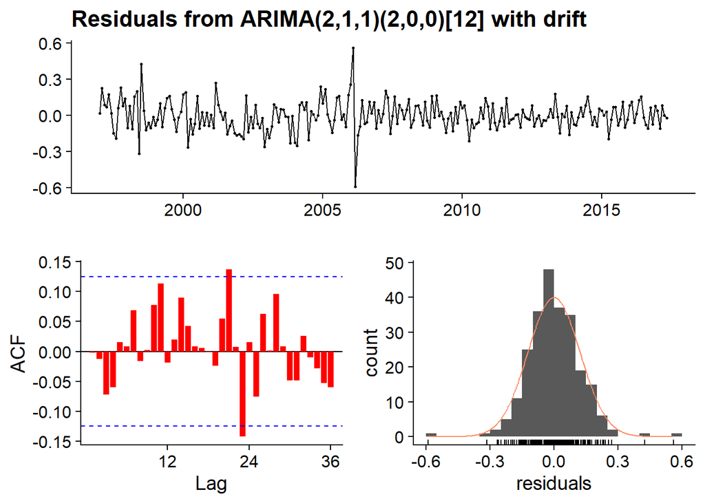

[output not shown]

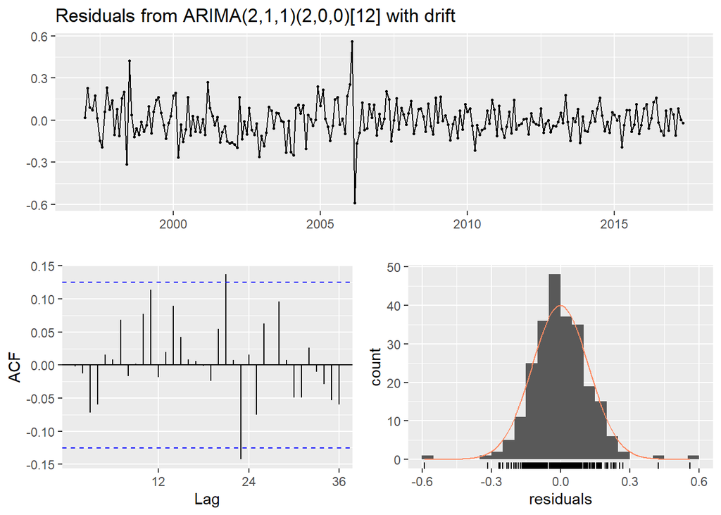

[output not shown]

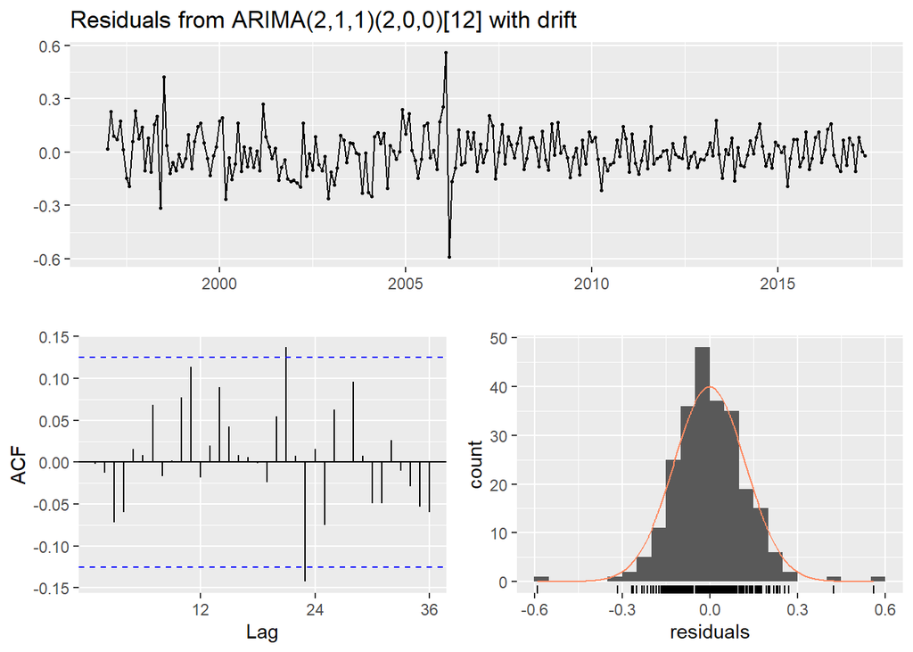

[output not shown]

```
##          Point Forecast       Lo 80    Hi 80       Lo 95    Hi 95
## Jun 2017       3.081191  2.92217160 3.240211  2.83799167 3.324391
## Jul 2017       3.038107  2.73870440 3.337510  2.58021017 3.496004
## Aug 2017       3.002284  2.54146274 3.463106  2.29751853 3.707050
## Sep 2017       2.958886  2.33757863 3.580193  2.00867838 3.909094
## Oct 2017       2.903089  2.11954185 3.686637  1.70475679 4.101422
## Nov 2017       2.857670  1.91591476 3.799425  1.41737980 4.297960
## Dec 2017       2.818959  1.72262214 3.915295  1.14225664 4.495661
## Jan 2018       2.761562  1.51592343 4.007200  0.85652230 4.666601
## Feb 2018       2.677773  1.28794328 4.067602  0.55221196 4.803334
## Mar 2018       2.619598  1.09103501 4.148160  0.28186278 4.957333
## Apr 2018       2.561125  0.89906044 4.223189  0.01921686 5.103032
## May 2018       2.484131  0.69370241 4.274559 -0.25409301 5.222354
## Jun 2018       2.387205  0.46898271 4.305428 -0.54646299 5.320874
## Jul 2018       2.306623  0.26322945 4.350017 -0.81847796 5.431725
## Aug 2018       2.244792  0.07876348 4.410822 -1.06786302 5.557448
## Sep 2018       2.200616 -0.08484597 4.486078 -1.29469640 5.695928
## Oct 2018       2.137103 -0.26465382 4.538860 -1.53606716 5.810273
## Nov 2018       2.092636 -0.42213477 4.607407 -1.75337399 5.938646
## Dec 2018       2.030307 -0.59430404 4.654919 -1.98368945 6.044304
## Jan 2019       1.966523 -0.76480820 4.697854 -2.21068767 6.143734
## Feb 2019       1.919026 -0.91604167 4.754094 -2.41683586 6.254888
## Mar 2019       1.855124 -1.08081675 4.791065 -2.63500987 6.345258
## Apr 2019       1.791178 -1.24291810 4.825274 -2.84907154 6.431427
## May 2019       1.725811 -1.40385907 4.855482 -3.06060652 6.512229
```

[output not shown]

[figure not shown]